# Презентация

Архитектура, параметры и организация беспроводных сетей

Автор

Богомолова Полина Петровна

Дата публикации

16 апреля 2026 г.

# Информация о докладчике

Богомолова Полина Петровна  
ФФМиЕН  
НКАбд01-25  
1032253562

# Содержание

- Актуальность темы
- Объект и предмет исследования
- Цель, гипотеза и задачи
- Научная новизна
- Практическая значимость
- Материалы и методы
- Введение
- Архитектура беспроводных сетей
- Основные параметры
- Технологии передачи
- Качество соединения
- Организация сети
- Безопасность
- Заключение
- Список литературы

# Актуальность темы

Актуальность исследования обусловлена массовым распространением беспроводных сетей и ростом требований к качеству цифровой связи.

Современные тенденции включают:

- увеличение числа подключённых устройств
- развитие облачных сервисов и IoT
- рост нагрузки на Wi-Fi инфраструктуру
- необходимость повышения безопасности передачи данных

# Объект и предмет исследования

Объект исследования — беспроводные сети передачи данных.

Предмет исследования — архитектура, параметры и методы организации беспроводных сетей, включая стандарты IEEE 802.11, режимы работы и технологии повышения эффективности.

# Цель, гипотеза и задачи

Цель исследования — анализ характеристик беспроводных сетей и факторов, влияющих на их производительность.

Гипотеза:

эффективность беспроводной сети зависит от выбора архитектуры, частоты работы и методов управления доступом к каналу.

Задачи исследования:

- изучить архитектуру Wi-Fi сетей
- рассмотреть режимы работы (infrastructure, ad-hoc, mesh)
- проанализировать влияние частоты и канала
- изучить технологии MU-MIMO и CSMA/CA
- рассмотреть параметры качества связи (SNR, латентность)
- исследовать методы защиты беспроводных сетей

# Научная новизна

Научная новизна заключается в систематизации характеристик беспроводных сетей и их влияния на качество связи.

В работе:

- обобщены архитектурные модели Wi-Fi
- проанализированы параметры, влияющие на производительность
- выделены ключевые технологии повышения эффективности
- рассмотрены современные подходы к организации сетей

# Практическая значимость

Практическая значимость заключается в возможности применения результатов при проектировании и настройке беспроводных сетей.

Результаты позволяют:

- повышать стабильность соединения
- уменьшать задержки и помехи
- оптимизировать параметры сети
- улучшать безопасность передачи данных

# Материалы и методы

Материалы исследования:

- научные источники по беспроводным сетям
- стандарты IEEE 802.11
- техническая документация Wi-Fi технологий
- открытые образовательные ресурсы

Методы исследования:

- анализ литературы
- сравнение характеристик сетей
- систематизация параметров
- обобщение технических решений

# Введение

Беспроводные сети — это способ передачи данных без использования кабельных соединений, основанный на радиосигналах.

Они являются основой современной цифровой инфраструктуры и обеспечивают мобильность пользователей.

Области применения:

- мобильная связь
- спутниковые системы
- корпоративные сети
- экстренная связь

# Беспроводная сеть

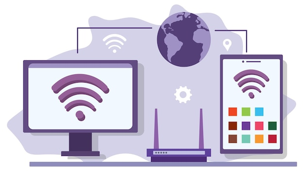

Беспроводная сеть

# Архитектура беспроводных сетей

IEEE 802.11 является основным стандартом Wi-Fi сетей.

Режимы работы:

- инфраструктурный — через точку доступа
- ad-hoc — прямое соединение устройств
- mesh — распределённая сеть узлов

Точка доступа обеспечивает подключение устройств и управление передачей данных.

# Основные параметры

Частотный диапазон влияет на свойства сети:

- 2,4 ГГц — больше покрытие, больше помех
- 5 ГГц — выше скорость, меньше помех

Также важны:

- ширина канала
- стандарт Wi-Fi
- технологии передачи данных

# Технологии передачи

MU-MIMO позволяет одновременно обслуживать несколько устройств.

CSMA/CA предотвращает коллизии при передаче данных в сети.

# Качество соединения

SNR определяет качество принимаемого сигнала.

Латентность — задержка передачи данных, важная для:

- видеосвязи
- онлайн-игр
- потокового видео

# Организация сети

При проектировании учитываются:

- зона покрытия
- количество пользователей
- физические препятствия

Для снижения помех используются разные каналы, особенно в диапазоне 5 ГГц.

# Безопасность

Основные протоколы:

- WPA2
- WPA3

Они обеспечивают шифрование и защиту от несанкционированного доступа.

# Заключение

Беспроводные сети являются ключевой частью современной цифровой инфраструктуры.

Основные направления развития:

- повышение скорости передачи данных
- снижение задержек
- повышение безопасности

# Список литературы

1. Беспроводная сеть // Википедия. - URL: https://en.wikipedia.org/wiki/Wireless_network
2. IEE 802.11 // Википедия. - URL: https://ru.wikipedia.org/wiki/IEEE_802.11
3. Беспроводная точка доступа // Википедия. - URL: https://ru.wikipedia.org/wiki/%D0%91%D0%B5%D1%81%D0%BF%D1%80%D0%BE%D0%B2%D0%BE%D0%B4%D0%BD%D0%B0%D1%8F_%D1%82%D0%BE%D1%87%D0%BA%D0%B0_%D0%B4%D0%BE%D1%81%D1%82%D1%83%D0%BF%D0%B0
4. Беспроводная ad-hoc сеть // Википедия. - URL: https://ru.wikipedia.org/wiki/%D0%91%D0%B5%D1%81%D0%BF%D1%80%D0%BE%D0%B2%D0%BE%D0%B4%D0%BD%D0%B0%D1%8F_ad-hoc-%D1%81%D0%B5%D1%82%D1%8C
5. Ячеистая топология // Википедия. - URL: https://ru.wikipedia.org/wiki/%D0%AF%D1%87%D0%B5%D0%B8%D1%81%D1%82%D0%B0%D1%8F_%D1%82%D0%BE%D0%BF%D0%BE%D0%BB%D0%BE%D0%B3%D0%B8%D1%8F?ysclid=mo04k1i0pu33362885
6. Диапазон частот Wi-Fi // t2. - URL: https://msk.t2.ru/journal/article/wi-fi-frequency-range
7. Технология MU MIMO // dns. - URL: https://club.dns-shop.ru/wiki/t-280-marshrutizatoryi/123538-tehnologiya-mu-mimo-v-routere-chto-eto-i-dlya-chego-nujna/
8. Что такое SNR в аудио? // 8ohm. - URL: https://8ohm.ru/news/chto-takoe-snr-v-audio-1486

# Спасибо за внимание

Спасибо за внимание!